# pH maalinger

Lærke

5/10/2021

Summary of pH measurement to determine possible buffer properties of the 3 mM NaCl in Ro water.  
Half of the samples were bobbles with atmospheric air overnight, to impact the carbonate system. About 500 mL solution was set to various pH, with 2M NaCl and 2M NaOH. When setting the pH it was very difficult to achieve a pH of 8, a lower concentratino of acid and base could be used to set the pH.  
One samples was prepared with a sodium-bicarbonate-carbonate buffer with initial pH at 9.2. The pH was measure intially (time 0) and following the pH was set about time 15 min.

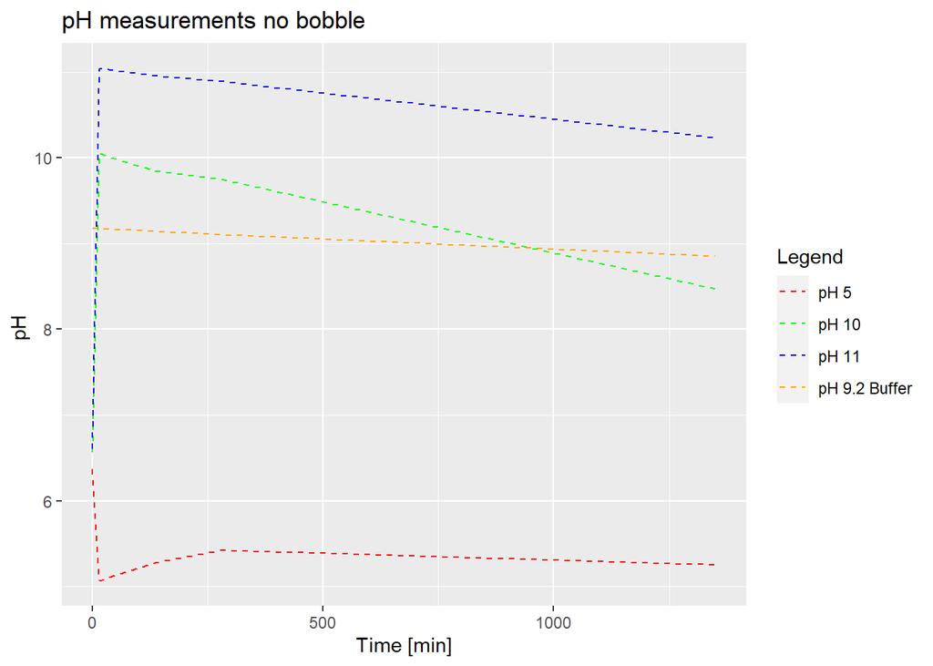